# Prediction Assignment Writeup

Luiz Fernando da Silva

August, 2015

Currently is possible to get a large volume of data about activities of our daily lives in a simply and cheaply way. In one study, accelerometer were placed on the belt, arm and barbells of 6 participants, they performed a movement in 5 different ways. This document seeks to create a model able to predict how a person is doing the same exercise.

```r
library(caret)
library(randomForest)
```

## Loading the data

The data is contained in two CSV files, one for the training data, which includes the variable `classe`, and another for testing, where the algorithm should provide what is the `classe`’.

```r
set.seed(1910)
training <- read.csv("pml-training.csv", header=TRUE, sep=",", na.strings=c("NA", "", "#DIV/0!"))
testing <- read.csv("pml-testing.csv", header=TRUE, sep=",", na.strings=c("NA", "", "#DIV/0!"))
```

Let’s check how many records exist for each `classe`:

```r
summary(training$classe)
```

```
##    A    B    C    D    E
## 5580 3797 3422 3216 3607
```

Since there are many variables in this data set we will remove the columns with close to zero variance:

```r
near_zero <- nearZeroVar(training,saveMetrics=TRUE)
training <- training[, !near_zero$nzv]
testing <- testing[, !near_zero$nzv]
```

There are still many variables with missing values, we will remove those that have less than 51% of data:

```r
lowDataCols <- c((colSums(!is.na(training[,-ncol(training)])) >= 0.51 * nrow(training)))
training <- training[, lowDataCols]
testing <- testing[, lowDataCols]
```

Other variables can influence the outcome but has no real importance, we will remove them also:

```r
drops <- c("X", "user_name", "raw_timestamp_part_1", "raw_timestamp_part_2", "cvtd_timestamp",
     "num_window")
training <- training[, !(names(training) %in% drops)]
testing <- testing[, !(names(testing) %in% drops)]
```

```r
inTrain <- createDataPartition(y=training$classe, p=0.7, list=FALSE)
final_training <- training[inTrain,]
final_validation <- training[inTrain,]
```

## Creating the model

To get a better accuracy in prediction will use randomForest algorithm.

```r
model <- randomForest(classe~., data=final_training)
```

We will validate the model:

```r
validation <- predict(model, newdata=final_validation)
confusionMatrix(validation, final_validation$classe)
```

```
## Confusion Matrix and Statistics
##
##           Reference
## Prediction    A    B    C    D    E
##          A 3906    0    0    0    0
##          B    0 2658    0    0    0
##          C    0    0 2396    0    0
##          D    0    0    0 2252    0
##          E    0    0    0    0 2525
##
## Overall Statistics
##
##                Accuracy : 1
##                  95% CI : (0.9997, 1)
##     No Information Rate : 0.2843
##     P-Value [Acc > NIR] : < 2.2e-16
##
##                   Kappa : 1
##  Mcnemar's Test P-Value : NA
##
## Statistics by Class:
##
##                      Class: A Class: B Class: C Class: D Class: E
## Sensitivity            1.0000   1.0000   1.0000   1.0000   1.0000
## Specificity            1.0000   1.0000   1.0000   1.0000   1.0000
## Pos Pred Value         1.0000   1.0000   1.0000   1.0000   1.0000
## Neg Pred Value         1.0000   1.0000   1.0000   1.0000   1.0000
## Prevalence             0.2843   0.1935   0.1744   0.1639   0.1838
## Detection Rate         0.2843   0.1935   0.1744   0.1639   0.1838
## Detection Prevalence   0.2843   0.1935   0.1744   0.1639   0.1838
## Balanced Accuracy      1.0000   1.0000   1.0000   1.0000   1.0000
```

```r
accuracy <- c(as.numeric(validation==final_validation$classe))
accuracy <- sum(accuracy) * 100 / nrow(final_validation)
```

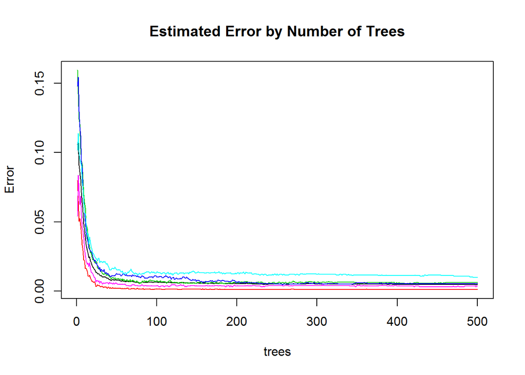

```r
plot(model, lty=c(1,1,1,1,1,1), main="Estimated Error by Number of Trees")
```

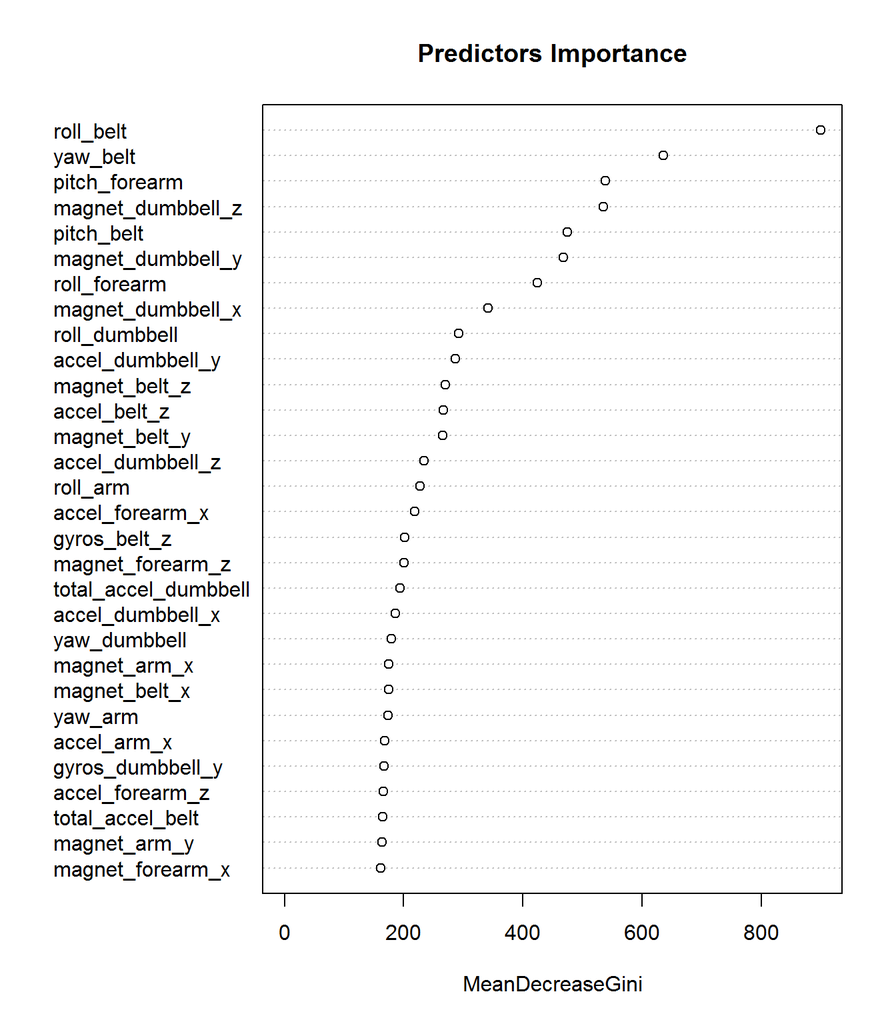

```r
varImpPlot(model, main="Predictors Importance")
```

## Testing the prediction

Now let’s test the prediction in a new data set of 20 records:

```r
test <- predict(model, newdata=testing)
test
```

```
##  1  2  3  4  5  6  7  8  9 10 11 12 13 14 15 16 17 18 19 20
##  B  A  B  A  A  E  D  B  A  A  B  C  B  A  E  E  A  B  B  B
## Levels: A B C D E
```

```r
test_table <- table(test)
test_table
```

```
## test
## A B C D E
## 7 8 1 1 3
```

For the second part of assignment:

```r
n = length(test)
for(i in 1:n){
  filename = paste0("problem_id_",i,".txt")
  write.table(test[i],file=filename,quote=FALSE,row.names=FALSE,col.names=FALSE)
}
```